# NYPD Shooting Incident Data Analysis

2025-06-30

install.packages(“ggplot2”) install.packages(“janitor”)

## 1. Data load

This data get from here “https://catalog.data.gov/dataset/nypd-shooting-incident-data-historic”

```r
data <- read_csv("NYPD_Shooting_Incident_Data__Historic_.csv")
glimpse(data)
```

```
## Rows: 29,744
## Columns: 21
## $ INCIDENT_KEY            <dbl> 231974218, 177934247, 255028563, 25384540, 726…
## $ OCCUR_DATE              <chr> "08/09/2021", "04/07/2018", "12/02/2022", "11/…
## $ OCCUR_TIME              <time> 01:06:00, 19:48:00, 22:57:00, 01:50:00, 01:58…
## $ BORO                    <chr> "BRONX", "BROOKLYN", "BRONX", "BROOKLYN", "BRO…
## $ LOC_OF_OCCUR_DESC       <chr> NA, NA, "OUTSIDE", NA, NA, NA, NA, NA, NA, NA,…
## $ PRECINCT                <dbl> 40, 79, 47, 66, 46, 42, 71, 69, 75, 69, 40, 42…
## $ JURISDICTION_CODE       <dbl> 0, 0, 0, 0, 0, 2, 0, 2, 0, 0, 0, 2, 0, 0, 2, 0…
## $ LOC_CLASSFCTN_DESC      <chr> NA, NA, "STREET", NA, NA, NA, NA, NA, NA, NA, …
## $ LOCATION_DESC           <chr> NA, NA, "GROCERY/BODEGA", "PVT HOUSE", "MULTI …
## $ STATISTICAL_MURDER_FLAG <lgl> FALSE, TRUE, FALSE, TRUE, TRUE, FALSE, TRUE, F…
## $ PERP_AGE_GROUP          <chr> NA, "25-44", "(null)", "UNKNOWN", "25-44", "18…
## $ PERP_SEX                <chr> NA, "M", "(null)", "U", "M", "M", NA, NA, "M",…
## $ PERP_RACE               <chr> NA, "WHITE HISPANIC", "(null)", "UNKNOWN", "BL…
## $ VIC_AGE_GROUP           <chr> "18-24", "25-44", "25-44", "18-24", "<18", "18…
## $ VIC_SEX                 <chr> "M", "M", "M", "M", "F", "M", "M", "M", "M", "…
## $ VIC_RACE                <chr> "BLACK", "BLACK", "BLACK", "BLACK", "BLACK", "…
## $ X_COORD_CD              <dbl> 1006343.0, 1000082.9, 1020691.0, 985107.3, 100…
## $ Y_COORD_CD              <dbl> 234270.0, 189064.7, 257125.0, 173349.8, 247502…
## $ Latitude                <dbl> 40.80967, 40.68561, 40.87235, 40.64249, 40.845…
## $ Longitude               <dbl> -73.92019, -73.94291, -73.86823, -73.99691, -7…
## $ Lon_Lat                 <chr> "POINT (-73.92019278899994 40.80967347200004)"…
```

```r
summary(data)
```

```
##   INCIDENT_KEY        OCCUR_DATE         OCCUR_TIME           BORO
##  Min.   :  9953245   Length:29744       Length:29744      Length:29744
##  1st Qu.: 67321140   Class :character   Class1:hms        Class :character
##  Median :109291972   Mode  :character   Class2:difftime   Mode  :character
##  Mean   :133850951                      Mode  :numeric
##  3rd Qu.:214741917
##  Max.   :299462478
##
##  LOC_OF_OCCUR_DESC     PRECINCT      JURISDICTION_CODE LOC_CLASSFCTN_DESC
##  Length:29744       Min.   :  1.00   Min.   :0.0000    Length:29744
##  Class :character   1st Qu.: 44.00   1st Qu.:0.0000    Class :character
##  Mode  :character   Median : 67.00   Median :0.0000    Mode  :character
##                     Mean   : 65.23   Mean   :0.3181
##                     3rd Qu.: 81.00   3rd Qu.:0.0000
##                     Max.   :123.00   Max.   :2.0000
##                                      NA's   :2
##  LOCATION_DESC      STATISTICAL_MURDER_FLAG PERP_AGE_GROUP
##  Length:29744       Mode :logical           Length:29744
##  Class :character   FALSE:23979             Class :character
##  Mode  :character   TRUE :5765              Mode  :character
##
##
##
##
##    PERP_SEX          PERP_RACE         VIC_AGE_GROUP        VIC_SEX
##  Length:29744       Length:29744       Length:29744       Length:29744
##  Class :character   Class :character   Class :character   Class :character
##  Mode  :character   Mode  :character   Mode  :character   Mode  :character
##
##
##
##
##    VIC_RACE           X_COORD_CD        Y_COORD_CD        Latitude
##  Length:29744       Min.   : 914928   Min.   :125757   Min.   :40.51
##  Class :character   1st Qu.:1000094   1st Qu.:183042   1st Qu.:40.67
##  Mode  :character   Median :1007826   Median :195506   Median :40.70
##                     Mean   :1009442   Mean   :208722   Mean   :40.74
##                     3rd Qu.:1016739   3rd Qu.:239980   3rd Qu.:40.83
##                     Max.   :1066815   Max.   :271128   Max.   :40.91
##                                                        NA's   :97
##    Longitude        Lon_Lat
##  Min.   :-74.25   Length:29744
##  1st Qu.:-73.94   Class :character
##  Median :-73.91   Mode  :character
##  Mean   :-73.91
##  3rd Qu.:-73.88
##  Max.   :-73.70
##  NA's   :97
```

## 2. Trends in the number of incidents by year

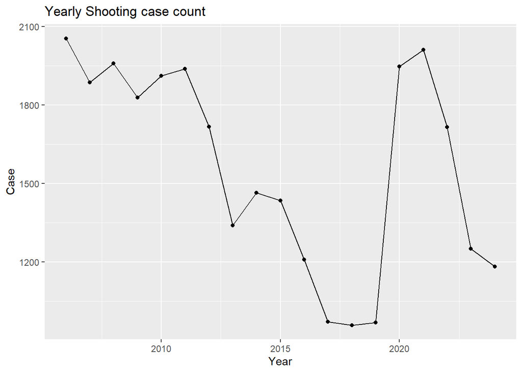

```r
data$OCCUR_DATE <- mdy(data$OCCUR_DATE)
data$YEAR <- year(data$OCCUR_DATE)

yearly_data <- data %>%
  count(YEAR)

ggplot(yearly_data, aes(x = YEAR, y = n)) +
  geom_line() +
  geom_point() +
  labs(title = "Yearly Shooting case count", x = "Year", y = "Case")
```

## 3. Monthly and weekly trends

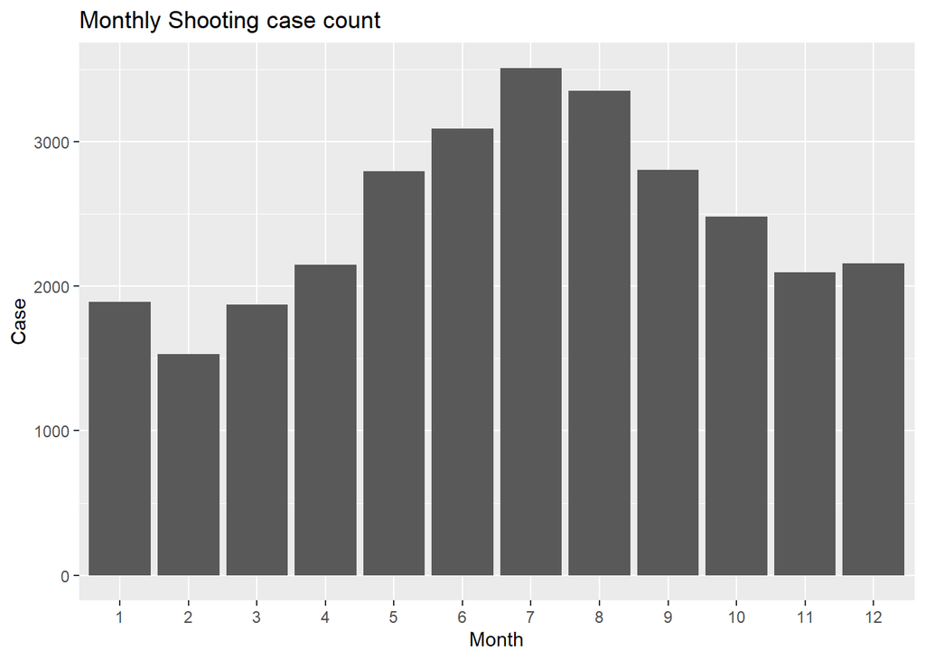

```r
data$MONTH <- month(data$OCCUR_DATE, label = TRUE)
data$WEEKDAY <- wday(data$OCCUR_DATE, label = TRUE)

ggplot(data, aes(x = MONTH)) +
  geom_bar() +
  labs(title = "Monthly Shooting case count", x = "Month", y = "Case")
```

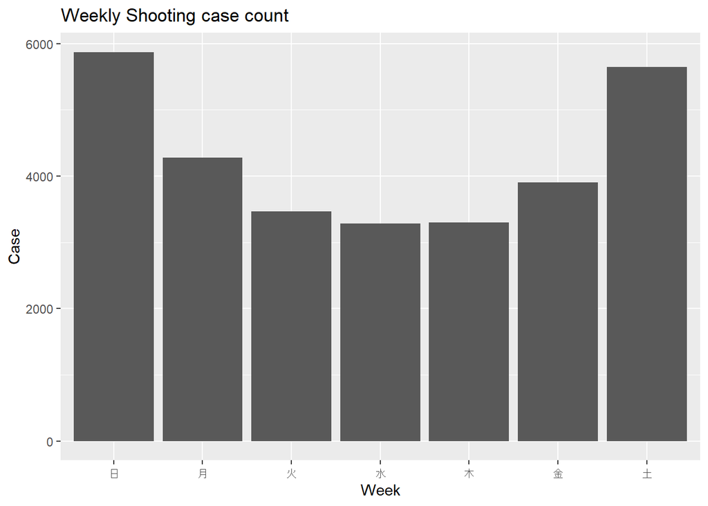

```r
ggplot(data, aes(x = WEEKDAY)) +
  geom_bar() +
  labs(title = "Weekly Shooting case count", x = "Week", y = "Case")
```

- Although between 2010-2019 declined, 2020 sharply increased. Recently, it has declined again.
- Furthermore, incidents tend to increase between May and September, with most occurring 1.5 times on weekends.

## 4. Number of incidents by district (BORO)

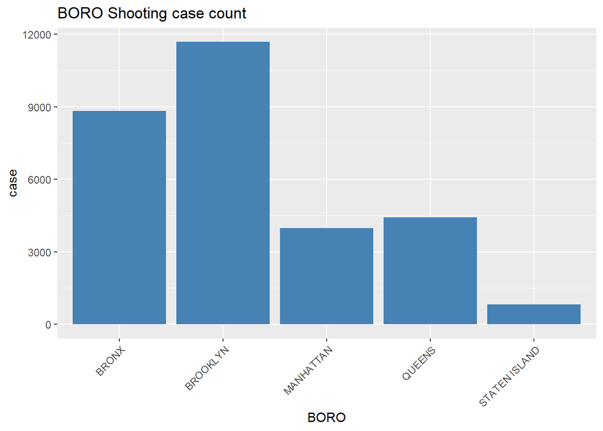

```r
ggplot(data, aes(x = BORO)) +
  geom_bar(fill = "steelblue") +
  labs(title = "BORO Shooting case count", x = "BORO", y = "case") +
  theme(axis.text.x = element_text(angle = 45, hjust = 1))
```

- Concentrated in specific locations, there seem to be hotspots.

## 5. Analysis about Victime&Perpetrator

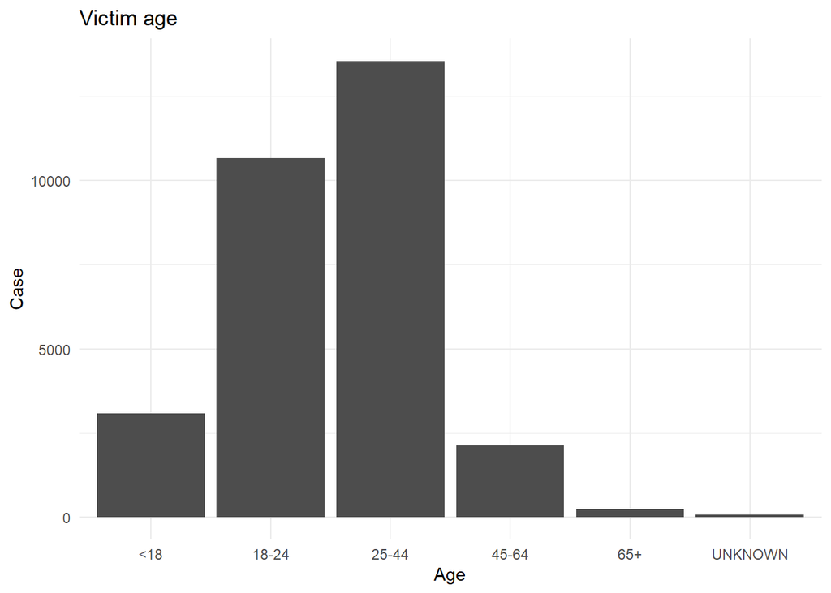

```r
valid_age_groups <- c("<18", "18-24", "25-44", "45-64", "65+", "UNKNOWN")

data %>%
  filter(
    !is.na(VIC_AGE_GROUP),
    VIC_AGE_GROUP %in% valid_age_groups  # ← この行が重要
  ) %>%
  mutate(VIC_AGE_GROUP = factor(VIC_AGE_GROUP, levels = valid_age_groups)) %>%
  ggplot(aes(x = VIC_AGE_GROUP)) +
  geom_bar(fill = "gray30") +
  labs(title = "Victim age", x = "Age", y = "Case") +
  theme_minimal()
```

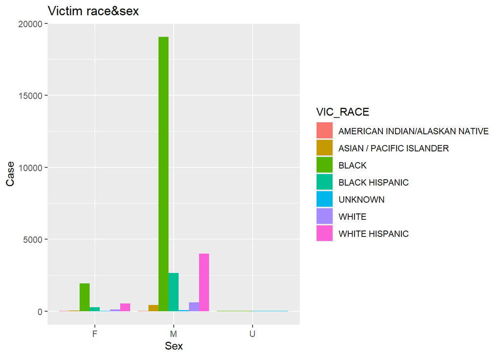

```r
ggplot(data, aes(x = VIC_SEX, fill = VIC_RACE)) +
  geom_bar(position = "dodge") +
  labs(title = "Victim race&sex", x = "Sex", y = "Case")
```

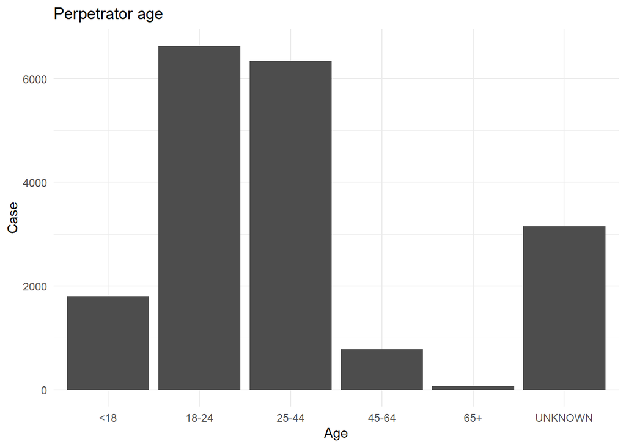

```r
valid_perp_age_groups <- c("<18", "18-24", "25-44", "45-64", "65+", "UNKNOWN")

data %>%
  filter(
    !is.na(PERP_AGE_GROUP),
    PERP_AGE_GROUP %in% valid_perp_age_groups
  ) %>%
  mutate(PERP_AGE_GROUP = factor(PERP_AGE_GROUP, levels = valid_perp_age_groups)) %>%
  ggplot(aes(x = PERP_AGE_GROUP)) +
  geom_bar(fill = "gray30") +
  labs(title = "Perpetrator age", x = "Age", y = "Case") +
  theme_minimal()
```

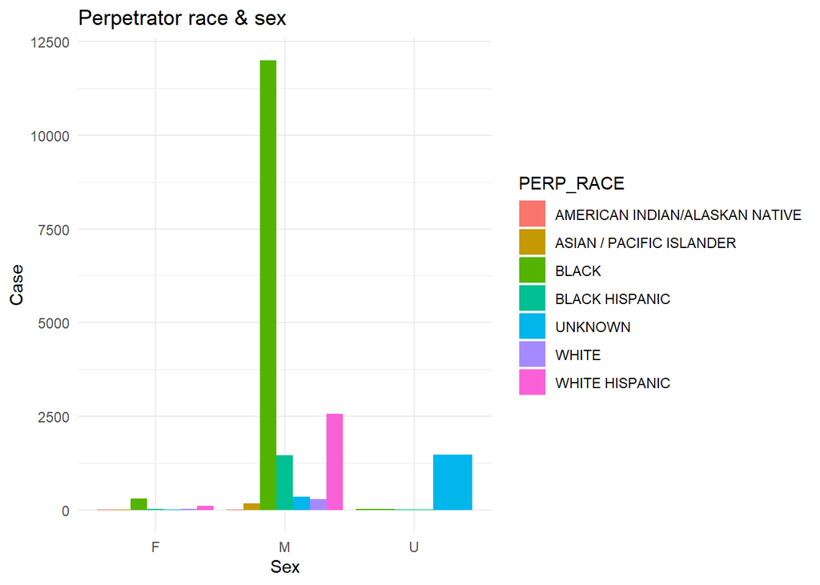

```r
data %>%
  filter(
    !is.na(PERP_SEX),
    !is.na(PERP_RACE),
    PERP_SEX != "(null)",
    PERP_RACE != "(null)"
  ) %>%
  ggplot(aes(x = PERP_SEX, fill = PERP_RACE)) +
  geom_bar(position = "dodge") +
  labs(title = "Perpetrator race & sex", x = "Sex", y = "Case") +
  theme_minimal()
```

- Most of the victims were between the ages of 18 and 44, with the majority being black, followed by Hispanic.
- The perpetrators are of the same age group as the victims, but I think there are many cases where the perpetrators are not identified.

## 6. Clustering analysis (K-means + PCA)

```r
library(dplyr)
library(factoextra)
library(ggpubr)
set.seed(123)
# Data preprocessing and clustering
clust_data <- data %>%
  select(VIC_SEX, VIC_AGE_GROUP, VIC_RACE, PERP_SEX, PERP_AGE_GROUP, PERP_RACE) %>%
  filter(across(everything(), ~ !is.na(.))) %>%
  mutate(across(everything(), as.factor)) %>%
  slice_sample(n = 1000)
```

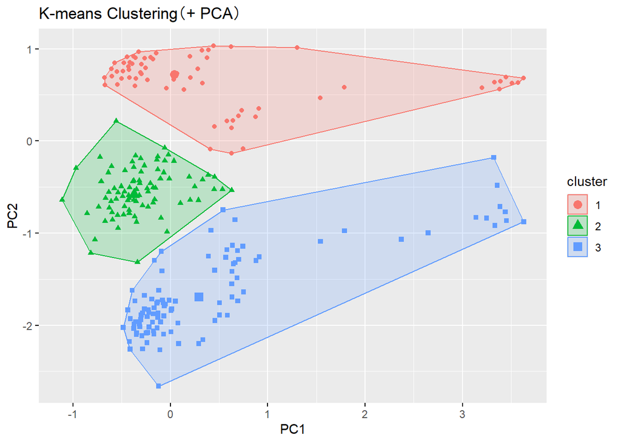

```r
# One-hot encode + constant sequence removal
clust_dummy <- model.matrix(~ . - 1, data = clust_data)
clust_dummy_filtered <- clust_dummy[, apply(clust_dummy, 2, function(x) length(unique(x)) > 1)]

# PCA + K-means
pca_result <- prcomp(clust_dummy_filtered,
                     center = TRUE,
                     scale. = TRUE,
                     rank. = 2)  # PC1〜2

kmeans_result <- kmeans(pca_result$x[, 1:2], centers = 3)

# Plot
fviz_cluster(
  list(data = pca_result$x[, 1:2], cluster = kmeans_result$cluster),
  geom = "point",
  main = "K-means Clustering（+ PCA）"
)
```

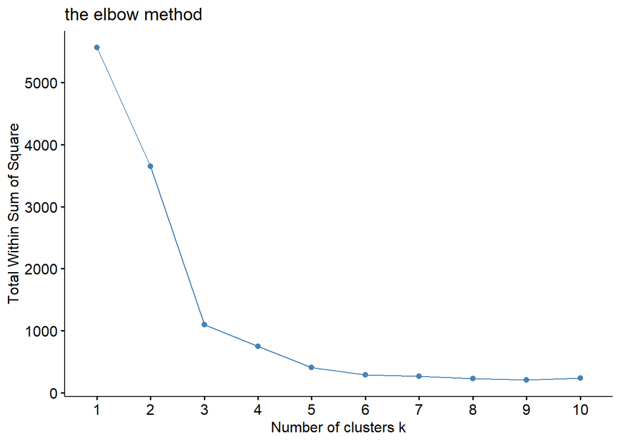

```r
# Estimating the optimal number of clusters using the elbow method
fviz_nbclust(pca_result$x[, 1:2], kmeans, method = "wss") +
  labs(title = "the elbow method")
```

- After performing PCA (Component=2), we confirmed the trend using k-mean clustering. The elbow method showed that three clusters were most appropriate, and we were able to successfully divide the data into three clusters.

## 8. Clustering analysis (K-means + PCA)

- In order to confirm which categories each cluster corresponds to, we checked the weights of each feature in each axis (PC1, 2) and cluster (n=1-3).

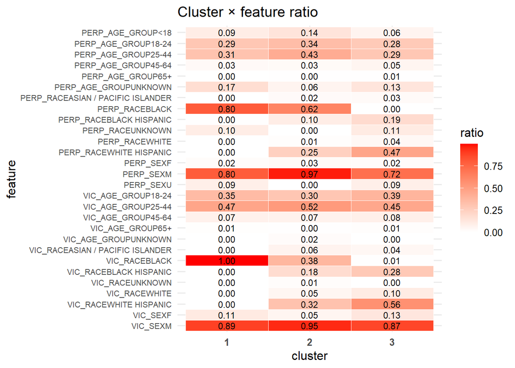

```r
# 1. Combining one-hot encoded data with clusters
clust_df <- as.data.frame(clust_dummy_filtered)
clust_df$cluster <- factor(kmeans_result$cluster)

# 2. Calculate the average (ratio) for each cluster.
cluster_means <- clust_df %>%
  group_by(cluster) %>%
  summarise(across(everything(), mean)) %>%
  ungroup()

# 3. Convert to tidy format
cluster_long <- cluster_means %>%
  pivot_longer(cols = -cluster, names_to = "Feature", values_to = "Proportion")

# 4. Heatmap
ggplot(cluster_long, aes(x = cluster, y = fct_rev(Feature), fill = Proportion)) +
  geom_tile(color = "white") +
  geom_text(aes(label = sprintf("%.2f", Proportion)), size = 3) +
  scale_fill_gradient(low = "white", high = "red") +
  labs(
    title = "Cluster × feature ratio",
    x = "cluster", y = "feature", fill = "ratio"
  ) +
  theme_minimal(base_size = 12) +
  theme(axis.text.x = element_text(face = "bold"),
        axis.text.y = element_text(size = 8))
```

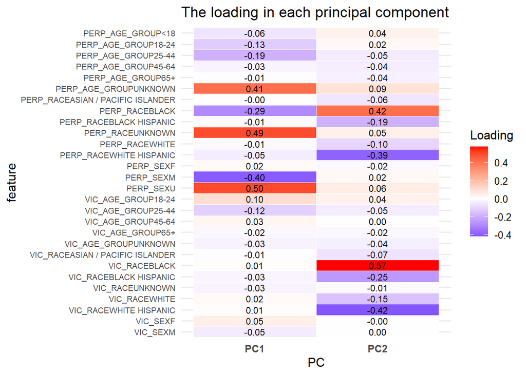

```r
# 1. PCA loading
loadings <- as.data.frame(pca_result$rotation)

# 2. Convert to tidy format
loadings_long <- loadings %>%
  mutate(Feature = rownames(.)) %>%
  pivot_longer(cols = starts_with("PC"), names_to = "Component", values_to = "Loading")

# 3. Heatmap
ggplot(loadings_long, aes(x = Component, y = fct_rev(Feature), fill = Loading)) +
  geom_tile(color = "white") +
  geom_text(aes(label = sprintf("%.2f", Loading)), size = 3) +
  scale_fill_gradient2(low = "blue", mid = "white", high = "red", midpoint = 0) +
  labs(
    title = "The loading in each principal component",
    x = "PC", y = "feature", fill = "Loading"
  ) +
  theme_minimal(base_size = 12) +
  theme(axis.text.x = element_text(face = "bold"),
        axis.text.y = element_text(size = 8))
```

- PC1 is the axis that mainly contains information about perpetrators, while PC2 shows a combination of information about victims and perpetrators.
- ①Cluster 1 consists of cases where the victim is black and the perpetrator is also black.
- ②Cluster 2 consists of cases where the victim is black&Hispanic and the perpetrator is Black.
- ③Cluster 3 consists of cases where the victim&perpetrator is Hispanic.

## Conlusion

- There is a clear trend in the months and days of the week when shooting incidents occur most frequently.
- There are also hot spots where they occur.
- Clustering reveals patterns in the attributes of victims and perpetrators.As a point for future consideration, I believe it should examine the racial composition of the population in the incident areas and compare it with other regions.